# LIMPIEZA DE DATOS

MIGUEL HERNÀNDEZ

2026-11-14

# LIMPIEZA DE DATOS

```r
list.files("../DATOS") # visualizar que archivos hay en esa carpeta
```

```
## [1] "dataset_clase_1.csv"
```

En esta linea es para cargamos la matriz de datos

```r
data <- read.csv("C:\\Users\\lumih\\OneDrive\\Documents\\IA\\Ciencia de datos\\DATOS\\dataset_clase_1.csv")
```

Visualizamos los datos

```r
data
```

[output not shown]

## EXPLORACIÓN DE LOS DATOS

```r
head(data)
```

```
##   ID Nombre  Apellido Edad Ingreso    Genero   Ciudad   Profesion
## 1  1   Juan     Pérez   25    1200 MASCULINO   Bogotá   Ingeniero
## 2  2    Ana     Gómez   30    1500  Femenino Medellín     Abogada
## 3  3 Carlos     Lopez   45    3000 MASCULINO     Cali      Medico
## 4  4  María Rodríguez   29      NA  FEMENINO   Bogotá     Docente
## 5  5  Pedro  Martinez   35   -2000 Masculino   bogotá Comerciante
## 6  6  Luisa Hernandez   NA    1800  FEMENINO     Cali   Ingeniera
##   Nivel_Educativo Estado_Civil Hijos               Email
## 1   Universitario      SOLTERO     0     juanp@gmail.com
## 2 Especialización       Casada     1 ana.gomez@gmail.com
## 3        Maestría       CASADO     2   carlosl@gmail.com
## 4   Universitario      Soltera     0     maria@gmail.com
## 5       Bachiller  UNION LIBRE     3     pedro@gmail.com
## 6   Universitario      Soltera     0     luisa@gmail.com
```

```r
tail(data)
```

```
##    ID  Nombre Apellido Edad Ingreso    Genero   Ciudad     Profesion
## 25 25 Natalia    Reyes   23    1000  Femenino     Cali    Estudiante
## 26 26   Oscar      Gil   37    1700 MASCULINO Medellín Administrador
## 27 27 Claudia    Pardo   34    1550  FEMENINO   Bogotá       Docente
## 28 28 Ricardo   Acosta  200    3000 MASCULINO     Cali    Empresario
## 29 29    Lina Bautista   28    1300  Femenino Medellín    Diseñadora
## 30 30    Juan    Pérez   25    1200 MASCULINO   Bogotá     Ingeniero
##    Nivel_Educativo Estado_Civil Hijos             Email
## 25   Universitario      Soltera     0 natalia@gmail.com
## 26   Universitario       Casado     2   oscar@gmail.com
## 27 Especialización       Casada     1 claudia@gmail.com
## 28        Maestría       Casado     4 ricardo@gmail.com
## 29   Universitario      Soltera     0    lina@gmail.com
## 30   Universitario      SOLTERO     0   juanp@gmail.com
```

```r
dim(data)
```

```
## [1] 30 12
```

```r
colnames(data)
```

```
##  [1] "ID"              "Nombre"          "Apellido"        "Edad"
##  [5] "Ingreso"         "Genero"          "Ciudad"          "Profesion"
##  [9] "Nivel_Educativo" "Estado_Civil"    "Hijos"           "Email"
```

```r
str(data)
```

```
## 'data.frame':    30 obs. of  12 variables:
##  $ ID             : int  1 2 3 4 5 6 7 8 9 10 ...
##  $ Nombre         : chr  "Juan" "Ana" "Carlos" "María" ...
##  $ Apellido       : chr  "Pérez" "Gómez" "Lopez" "Rodríguez" ...
##  $ Edad           : num  25 30 45 29 35 NA 25 40 22 28 ...
##  $ Ingreso        : num  1200 1500 3000 NA -2000 1800 1200 50000 1100 1300 ...
##  $ Genero         : chr  "MASCULINO" "Femenino" "MASCULINO" "FEMENINO" ...
##  $ Ciudad         : chr  "Bogotá" "Medellín" "Cali" "Bogotá" ...
##  $ Profesion      : chr  "Ingeniero" "Abogada" "Medico" "Docente" ...
##  $ Nivel_Educativo: chr  "Universitario" "Especialización" "Maestría" "Universitario" ...
##  $ Estado_Civil   : chr  "SOLTERO" "Casada" "CASADO" "Soltera" ...
##  $ Hijos          : int  0 1 2 0 3 0 0 2 0 0 ...
##  $ Email          : chr  "juanp@gmail.com" "ana.gomez@gmail.com" "carlosl@gmail.com" "maria@gmail.com" ...
```

```r
freq_profesion <- table(data$Profesion)

freq_profesion
```

```
##
##       Abogada Administrador   Comerciante      Contador    Diseñadora
##             2             2             2             2             2
##       Docente    Empresario    Estudiante     Ingeniera     Ingeniero
##             3             2             3             1             8
##        Medico     Psicologa
##             1             2
```

```r
tabla_profesion <- data.frame(sort(table(data$Profesion),
                                      decreasing = TRUE))

colnames(tabla_profesion) <- c("Profesion", "Frecuencia")

tabla_profesion
```

```
##        Profesion Frecuencia
## 1      Ingeniero          8
## 2        Docente          3
## 3     Estudiante          3
## 4        Abogada          2
## 5  Administrador          2
## 6    Comerciante          2
## 7       Contador          2
## 8     Diseñadora          2
## 9     Empresario          2
## 10     Psicologa          2
## 11     Ingeniera          1
## 12        Medico          1
```

```r
freq_Genero <- table(data$Genero)

freq_Genero
```

```
##
##  Femenino  FEMENINO Masculino MASCULINO
##         8         5         1        16
```

```r
tabla_Genero <- data.frame(sort(table(data$Genero),
                                      decreasing = TRUE))

colnames(tabla_Genero) <- c("Genero", "Frecuencia")

tabla_Genero
```

```
##      Genero Frecuencia
## 1 MASCULINO         16
## 2  Femenino          8
## 3  FEMENINO          5
## 4 Masculino          1
```

```r
freq_Ciudad <- table(data$Ciudad)

freq_Ciudad
```

```
##
##   bogota   bogotá   Bogotá     Cali Medellín
##        1        1       11        9        8
```

```r
tabla_Ciudad <- data.frame(sort(table(data$Ciudad),
                                      decreasing = TRUE))

colnames(tabla_Ciudad) <- c("Ciudad", "Frecuencia")

tabla_Ciudad
```

```
##     Ciudad Frecuencia
## 1   Bogotá         11
## 2     Cali          9
## 3 Medellín          8
## 4   bogota          1
## 5   bogotá          1
```

```r
freq_Nivel_Educativo <- table(data$Nivel_Educativo)

freq_Nivel_Educativo
```

```
##
##       Bachiller Especialización        Maestría   Universitario
##               2               6               4              18
```

```r
tabla_Nivel_Educativo <- data.frame(sort(table(data$Nivel_Educativo),
                                      decreasing = TRUE))

colnames(tabla_Nivel_Educativo) <- c("Nivel_Educativo", "Frecuencia")

tabla_Nivel_Educativo
```

```
##   Nivel_Educativo Frecuencia
## 1   Universitario         18
## 2 Especialización          6
## 3        Maestría          4
## 4       Bachiller          2
```

```r
summary(data$Ingreso)
```

```
##    Min. 1st Qu.  Median    Mean 3rd Qu.    Max.     NAs
##   -2000    1200    1325    3200    1625   50000       2
```

** tenemos un problema con el ingreso negativo el cual no es adecuado**

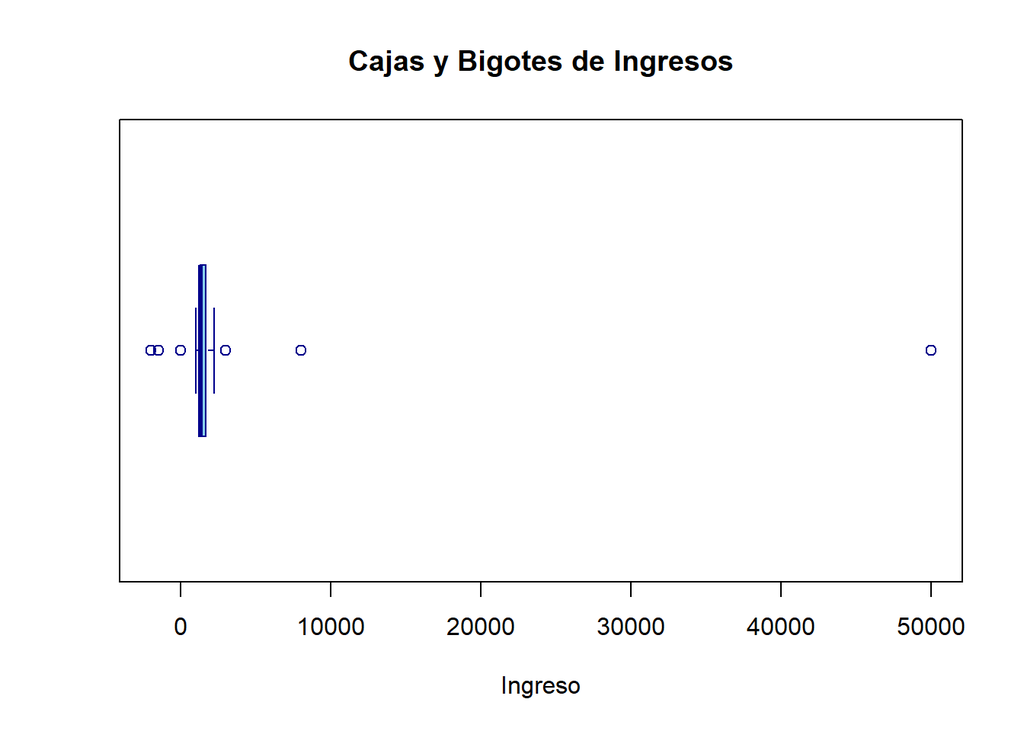

```r
boxplot(
  data$Ingreso,
  horizontal = TRUE,
  col = "skyblue",
  border = "darkblue",
  main = "Cajas y Bigotes de Ingresos",
  xlab = "Ingreso")
```

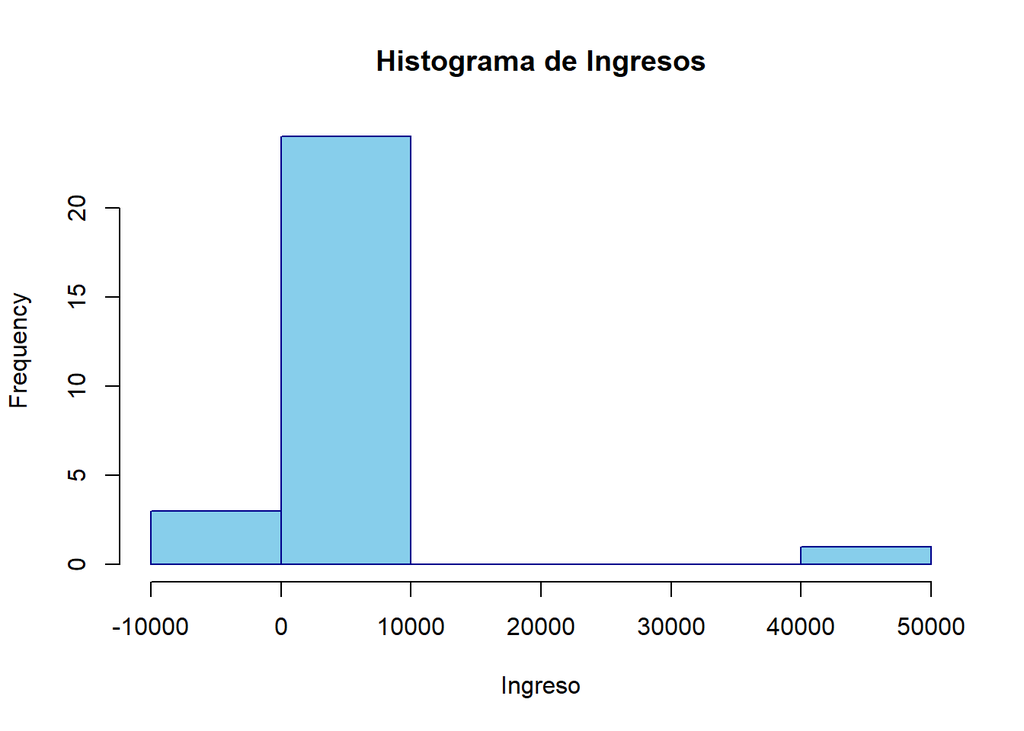

```r
hist(
  data$Ingreso,
  horizontal = TRUE,
  col = "skyblue",
  border = "darkblue",
  main = "Histograma de Ingresos",
  xlab = "Ingreso")
```

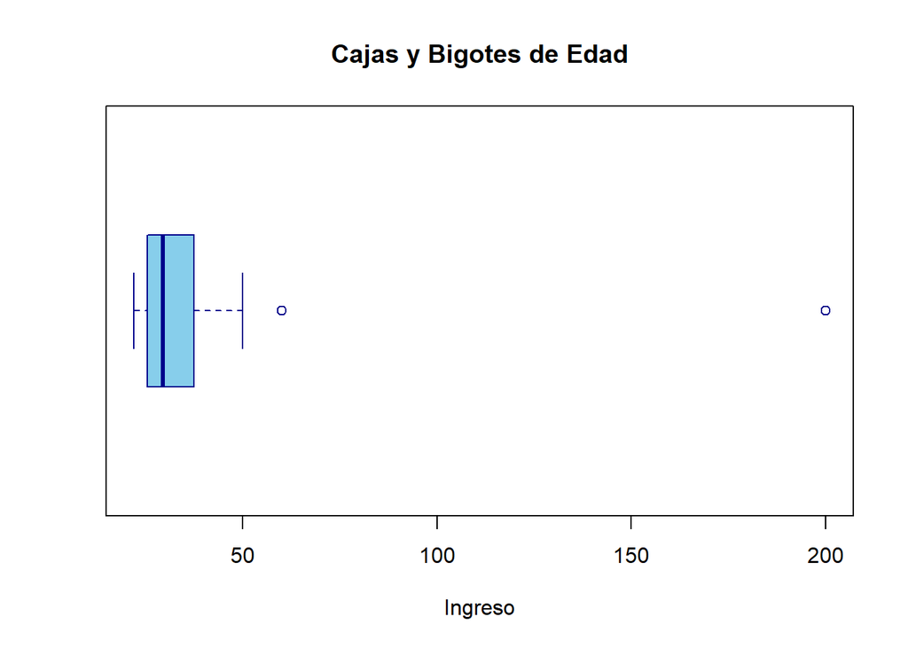

```r
boxplot(
  data$Edad,
  horizontal = TRUE,
  col = "skyblue",
  border = "darkblue",
  main = "Cajas y Bigotes de Edad",
  xlab = "Ingreso")
```

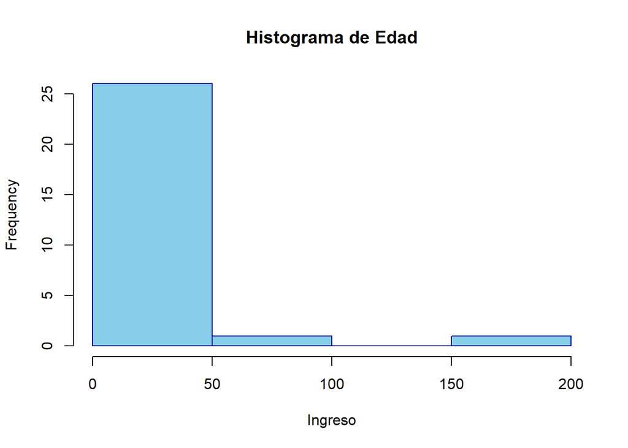

```r
hist(
  data$Edad,
  horizontal = TRUE,
  col = "skyblue",
  border = "darkblue",
  main = "Histograma de Edad",
  xlab = "Ingreso")
```

# 5. Limpieza de datos

## Valores faltantes

Valores perdidos en todo el data frame

```r
# Número total de datos perdidos en el dataframe
total_na <- sum(is.na(data))

print(paste("Total de datos perdidos:", total_na))
```

```
## [1] "Total de datos perdidos: 4"
```

Valores faltantes por columnas

```r
library(dplyr)
# Número de datos perdidos por columna
na_por_columna <- colSums(is.na(data))

# Crear un dataframe con los resultados

tabla_na <- data.frame(
  Columna = names(na_por_columna), # obtiene los nombres de las columnas
  Datos_Perdidos = na_por_columna # contiene la cantidad de NA por variable
)

# tabla_na
# Agregar una fila con el total de datos perdidos

tabla_na <- rbind(tabla_na, data.frame(Columna = "Total", Datos_Perdidos = total_na)) # rbind() agrega filas a una tabla, una fila con Total y datos perdidos


#tabla_na

# Ordenar la tabla en orden descendente
tabla_na_ordenada <- tabla_na %>%
  filter(Columna != "Total") %>%  # Excluir la fila "Total"
  arrange(desc(Datos_Perdidos)) %>%  # Ordenar de mayor a menor
  rbind(data.frame(Columna = "Total", Datos_Perdidos = total_na))  # Agregar la fila "Total" al final

tabla_na_ordenada
```

```
##                         Columna Datos_Perdidos
## Edad                       Edad              2
## Ingreso                 Ingreso              2
## ID                           ID              0
## Nombre                   Nombre              0
## Apellido               Apellido              0
## Genero                   Genero              0
## Ciudad                   Ciudad              0
## Profesion             Profesion              0
## Nivel_Educativo Nivel_Educativo              0
## Estado_Civil       Estado_Civil              0
## Hijos                     Hijos              0
## Email                     Email              0
## 1                         Total              4
```

## Total Datos Duplicados

identificar los datos perdidos repetidos,

```r
sum(duplicated(data))
```

```
## [1] 0
```

```r
data[duplicated(data), ]
```

```
##  [1] ID              Nombre          Apellido        Edad
##  [5] Ingreso         Genero          Ciudad          Profesion
##  [9] Nivel_Educativo Estado_Civil    Hijos           Email
## <0 rows> (o 0- extensión row.names)
```

```r
filas_repetidas <- data[c(1, 7, 30), ]
filas_repetidas
```

```
##    ID Nombre Apellido Edad Ingreso    Genero Ciudad Profesion Nivel_Educativo
## 1   1   Juan    Pérez   25    1200 MASCULINO Bogotá Ingeniero   Universitario
## 7   7   Juan    Pérez   25    1200 MASCULINO Bogotá Ingeniero   Universitario
## 30 30   Juan    Pérez   25    1200 MASCULINO Bogotá Ingeniero   Universitario
##    Estado_Civil Hijos           Email
## 1       SOLTERO     0 juanp@gmail.com
## 7       SOLTERO     0 juanp@gmail.com
## 30      SOLTERO     0 juanp@gmail.com
```

```r
data_sin <-(data[ , -1])
head(data_sin)
```

```
##   Nombre  Apellido Edad Ingreso    Genero   Ciudad   Profesion Nivel_Educativo
## 1   Juan     Pérez   25    1200 MASCULINO   Bogotá   Ingeniero   Universitario
## 2    Ana     Gómez   30    1500  Femenino Medellín     Abogada Especialización
## 3 Carlos     Lopez   45    3000 MASCULINO     Cali      Medico        Maestría
## 4  María Rodríguez   29      NA  FEMENINO   Bogotá     Docente   Universitario
## 5  Pedro  Martinez   35   -2000 Masculino   bogotá Comerciante       Bachiller
## 6  Luisa Hernandez   NA    1800  FEMENINO     Cali   Ingeniera   Universitario
##   Estado_Civil Hijos               Email
## 1      SOLTERO     0     juanp@gmail.com
## 2       Casada     1 ana.gomez@gmail.com
## 3       CASADO     2   carlosl@gmail.com
## 4      Soltera     0     maria@gmail.com
## 5  UNION LIBRE     3     pedro@gmail.com
## 6      Soltera     0     luisa@gmail.com
```

```r
sum(duplicated(data_sin))
```

```
## [1] 2
```

```r
data[duplicated(data_sin), ]
```

```
##    ID Nombre Apellido Edad Ingreso    Genero Ciudad Profesion Nivel_Educativo
## 7   7   Juan    Pérez   25    1200 MASCULINO Bogotá Ingeniero   Universitario
## 30 30   Juan    Pérez   25    1200 MASCULINO Bogotá Ingeniero   Universitario
##    Estado_Civil Hijos           Email
## 7       SOLTERO     0 juanp@gmail.com
## 30      SOLTERO     0 juanp@gmail.com
```

```r
filas_repetidas <- data_sin[c(1, 7, 30), ]
filas_repetidas
```

```
##    Nombre Apellido Edad Ingreso    Genero Ciudad Profesion Nivel_Educativo
## 1    Juan    Pérez   25    1200 MASCULINO Bogotá Ingeniero   Universitario
## 7    Juan    Pérez   25    1200 MASCULINO Bogotá Ingeniero   Universitario
## 30   Juan    Pérez   25    1200 MASCULINO Bogotá Ingeniero   Universitario
##    Estado_Civil Hijos           Email
## 1       SOLTERO     0 juanp@gmail.com
## 7       SOLTERO     0 juanp@gmail.com
## 30      SOLTERO     0 juanp@gmail.com
```

```r
data_sin <- data[!duplicated(data[ , -1]), ]
head(data_sin)
```

```
##   ID Nombre  Apellido Edad Ingreso    Genero   Ciudad   Profesion
## 1  1   Juan     Pérez   25    1200 MASCULINO   Bogotá   Ingeniero
## 2  2    Ana     Gómez   30    1500  Femenino Medellín     Abogada
## 3  3 Carlos     Lopez   45    3000 MASCULINO     Cali      Medico
## 4  4  María Rodríguez   29      NA  FEMENINO   Bogotá     Docente
## 5  5  Pedro  Martinez   35   -2000 Masculino   bogotá Comerciante
## 6  6  Luisa Hernandez   NA    1800  FEMENINO     Cali   Ingeniera
##   Nivel_Educativo Estado_Civil Hijos               Email
## 1   Universitario      SOLTERO     0     juanp@gmail.com
## 2 Especialización       Casada     1 ana.gomez@gmail.com
## 3        Maestría       CASADO     2   carlosl@gmail.com
## 4   Universitario      Soltera     0     maria@gmail.com
## 5       Bachiller  UNION LIBRE     3     pedro@gmail.com
## 6   Universitario      Soltera     0     luisa@gmail.com
```

Eliminamos los datos duplicados

```r
dim(data_sin)
```

```
## [1] 28 12
```

** CLASE 14/11/2026** ## COMO ELIMINAR DATOS PERDIDOS

```r
data_limpia <- na.omit(data_sin)
data_limpia
```

```
##    ID    Nombre Apellido Edad Ingreso    Genero   Ciudad     Profesion
## 1   1      Juan    Pérez   25    1200 MASCULINO   Bogotá     Ingeniero
## 2   2       Ana    Gómez   30    1500  Femenino Medellín       Abogada
## 3   3    Carlos    Lopez   45    3000 MASCULINO     Cali        Medico
## 5   5     Pedro Martinez   35   -2000 Masculino   bogotá   Comerciante
## 8   8    Andres   Garcia   40   50000 MASCULINO Medellín    Empresario
## 9   9     Sofía     Diaz   22    1100  Femenino     Cali    Estudiante
## 10 10    Camilo   torres   28    1300 MASCULINO   Bogotá     Ingeniero
## 11 11     Laura Martínez   31    1400  Femenino Medellín     Psicologa
## 12 12     Diego  Ramirez   50       0 MASCULINO     Cali      Contador
## 13 13 Valentina   Castro   27    1250  FEMENINO   Bogotá    Diseñadora
## 15 15    Miguel   Ortega   60    8000 MASCULINO     Cali Administrador
## 16 16     Paula   Vargas   24    1150  Femenino   Bogotá    Estudiante
## 17 17    Andrea  Morales   29    1350  FEMENINO     Cali       Abogada
## 19 19   Juliana  Navarro   26    1250  Femenino   Bogotá       Docente
```

[output cut: 35 more lines]

```r
dim(data_limpia)
```

```
## [1] 24 12
```

## DEJAR VARIABLES SOLO CON LA PRIMERA LETRA EN MAYÚSCULA

```r
# Variables cualitativas
vars_cualitativas <- c(
  "Nombre",
  "Apellido",
  "Genero",
  "Ciudad",
  "Profesion",
  "Nivel_Educativo",
  "Estado_Civil",
  "Email"
)
```

```r
# Quitar tildes usando iconv()
data_limpia[vars_cualitativas] <- lapply(
  data_limpia[vars_cualitativas],
  function(x) {
    x <- as.character(x)
    x <- tolower(x)
    x <- iconv(x, from = "UTF-8", to = "ASCII//TRANSLIT")
    paste0(
      toupper(substr(x, 1, 1)),
      substr(x, 2, nchar(x))
    )
  }
)
```

```r
data_limpia
```

```
##    ID    Nombre Apellido Edad Ingreso    Genero   Ciudad     Profesion
## 1   1      Juan    Perez   25    1200 Masculino   Bogota     Ingeniero
## 2   2       Ana    Gomez   30    1500  Femenino Medellin       Abogada
## 3   3    Carlos    Lopez   45    3000 Masculino     Cali        Medico
## 5   5     Pedro Martinez   35   -2000 Masculino   Bogota   Comerciante
## 8   8    Andres   Garcia   40   50000 Masculino Medellin    Empresario
## 9   9     Sofia     Diaz   22    1100  Femenino     Cali    Estudiante
## 10 10    Camilo   Torres   28    1300 Masculino   Bogota     Ingeniero
## 11 11     Laura Martinez   31    1400  Femenino Medellin     Psicologa
## 12 12     Diego  Ramirez   50       0 Masculino     Cali      Contador
## 13 13 Valentina   Castro   27    1250  Femenino   Bogota    Disenadora
## 15 15    Miguel   Ortega   60    8000 Masculino     Cali Administrador
## 16 16     Paula   Vargas   24    1150  Femenino   Bogota    Estudiante
## 17 17    Andrea  Morales   29    1350  Femenino     Cali       Abogada
## 19 19   Juliana  Navarro   26    1250  Femenino   Bogota       Docente
```

[output cut: 35 more lines]

```r
tabla_Genero_2 <- data.frame(sort(table(data_limpia$Genero),
                                      decreasing = TRUE))

colnames(tabla_Genero) <- c("Genero", "Frecuencia")

tabla_Genero_2
```

```
##        Var1 Freq
## 1 Masculino   13
## 2  Femenino   11
```

```r
tabla_Nivel_Educativo_2 <- data.frame(sort(table(data_limpia$Nivel_Educativo),
                                      decreasing = TRUE))

colnames(tabla_Nivel_Educativo) <- c("Nivel_Educativo", "Frecuencia")

tabla_Nivel_Educativo_2
```

```
##              Var1 Freq
## 1   Universitario   13
## 2 Especializacion    5
## 3        Maestria    4
## 4       Bachiller    2
```

```r
tabla_Ciudad_2 <- data.frame(sort(table(data_limpia$Ciudad),
                                      decreasing = TRUE))

colnames(tabla_Ciudad) <- c("Ciudad", "Frecuencia")

tabla_Ciudad_2
```

```
##       Var1 Freq
## 1   Bogota   10
## 2     Cali    8
## 3 Medellin    6
```

## Cambiar casado y casada a: Casado, y soltero y soltera a: Soltero, en una nueva columna.

```r
data_limpia$Estado_Civil_Limpio <- ifelse(
  tolower(data_limpia$Estado_Civil) %in% c("casado", "casada"),
  "Casado",
  ifelse(
    tolower(data_limpia$Estado_Civil) %in% c("soltero", "soltera"),
    "Soltero",
    data_limpia$Estado_Civil
  )
)
```

```r
table(data_limpia$Estado_Civil_Limpio)
```

```
##
##      Casado     Soltero Union libre
##          11          11           2
```

## CORRECCIONES DE ERRORES O INCONSISTENCIAS

ANALISIS DE LA VARIABLE INGRESO DEL DATAFRAME

```r
summary(data_limpia$Ingreso)
```

```
##    Min. 1st Qu.  Median    Mean 3rd Qu.    Max.
##   -2000    1188    1325    3498    1625   50000
```

```r
# Mostrar filas donde Ingreso es negativo
data_limpia[data_limpia$Ingreso <= 0, ]
```

```
##    ID Nombre Apellido Edad Ingreso    Genero Ciudad   Profesion Nivel_Educativo
## 5   5  Pedro Martinez   35   -2000 Masculino Bogota Comerciante       Bachiller
## 12 12  Diego  Ramirez   50       0 Masculino   Cali    Contador   Universitario
## 21 21  Pedro Martinez   35   -1500 Masculino Bogota Comerciante       Bachiller
##    Estado_Civil Hijos           Email Estado_Civil_Limpio
## 5   Union libre     3 Pedro@gmail.com         Union libre
## 12       Casado     2 Diego@gmail.com              Casado
## 21  Union libre     3 Pedro@gmail.com         Union libre
```

```r
summary(data_limpia$Edad)
```

```
##    Min. 1st Qu.  Median    Mean 3rd Qu.    Max.
##   22.00   26.75   30.50   40.00   38.50  200.00
```

```r
# Muestra los mayores a 100 años
data_limpia[data_limpia$Edad >= 100, ]
```

```
##    ID  Nombre Apellido Edad Ingreso    Genero Ciudad  Profesion Nivel_Educativo
## 28 28 Ricardo   Acosta  200    3000 Masculino   Cali Empresario        Maestria
##    Estado_Civil Hijos             Email Estado_Civil_Limpio
## 28       Casado     4 Ricardo@gmail.com              Casado
```

```r
data_limpia[data_limpia$Edad <= 0|data_limpia$Edad >= 100,  ]
```

```
##    ID  Nombre Apellido Edad Ingreso    Genero Ciudad  Profesion Nivel_Educativo
## 28 28 Ricardo   Acosta  200    3000 Masculino   Cali Empresario        Maestria
##    Estado_Civil Hijos             Email Estado_Civil_Limpio
## 28       Casado     4 Ricardo@gmail.com              Casado
```

```r
data_limpia[data_limpia$Hijos < 0|data_limpia$Hijos >= 12,  ]
```

```
##  [1] ID                  Nombre              Apellido
##  [4] Edad                Ingreso             Genero
##  [7] Ciudad              Profesion           Nivel_Educativo
## [10] Estado_Civil        Hijos               Email
## [13] Estado_Civil_Limpio
## <0 rows> (o 0- extensión row.names)
```

```r
data_sin_errores <- data_limpia[
  !(data_limpia$Edad <= 0 | data_limpia$Edad > 100 |
    data_limpia$Ingreso < 0),
]
```

```r
data_sin_errores
```

```
##    ID    Nombre Apellido Edad Ingreso    Genero   Ciudad     Profesion
## 1   1      Juan    Perez   25    1200 Masculino   Bogota     Ingeniero
## 2   2       Ana    Gomez   30    1500  Femenino Medellin       Abogada
## 3   3    Carlos    Lopez   45    3000 Masculino     Cali        Medico
## 8   8    Andres   Garcia   40   50000 Masculino Medellin    Empresario
## 9   9     Sofia     Diaz   22    1100  Femenino     Cali    Estudiante
## 10 10    Camilo   Torres   28    1300 Masculino   Bogota     Ingeniero
## 11 11     Laura Martinez   31    1400  Femenino Medellin     Psicologa
## 12 12     Diego  Ramirez   50       0 Masculino     Cali      Contador
## 13 13 Valentina   Castro   27    1250  Femenino   Bogota    Disenadora
## 15 15    Miguel   Ortega   60    8000 Masculino     Cali Administrador
## 16 16     Paula   Vargas   24    1150  Femenino   Bogota    Estudiante
## 17 17    Andrea  Morales   29    1350  Femenino     Cali       Abogada
## 19 19   Juliana  Navarro   26    1250  Femenino   Bogota       Docente
## 20 20      Juan    Perez   25    1200 Masculino   Bogota     Ingeniero
```

[output cut: 29 more lines]

```r
dim(data_sin_errores)
```

```
## [1] 21 13
```

## IDENTIFICACIÓN DE VALORES ATIPICOS

El análisis y la detección de datos atípicos (outliers) constituyen una etapa fundamental en la limpieza y exploración de datos, ya que estas observaciones extremas pueden distorsionar significativamente las medidas de tendencia central, inflar la varianza y comprometer la validez de los modelos estadísticos. Para identificar estas anomalías de manera objetiva en nuestro conjunto de datos, empleamos el criterio del Rango Intercuartílico (IQR), el cual mide la dispersión del 50 % central de la distribución mediante la diferencia entre el tercer cuartil (Q₃) y el primer cuartil (Q₁). Bajo este enfoque no paramétrico, se establece como dato atípico cualquier observación que se sitúe por debajo del límite inferior definido por Q₁ - 1.5 × IQR o por encima del límite superior calculado como Q₃ + 1.5 × IQR. En el entorno de R, la implementación de este procedimiento se integra de forma directa mediante funciones estadísticas base y herramientas de visualización exploratoria. Para el diagnóstico visual, se recurre a los diagramas de caja (boxplots), donde los valores que superan los bigotes del gráfico se representan como puntos aislados, facilitando una inspección inmediata de la asimetría y la presencia de extremos. De manera complementaria, la extracción programática de estos registros se realiza calculando los cuantiles con la función quantile() o utilizando boxplot.stats(variable)$out, lo que permite aislar, documentar y decidir de forma reproducible si dichos valores corresponden a errores de medición o a fenómenos genuinos dentro de la muestra.

```r
# Calcular cuartiles
Q1 <- quantile(data_sin_errores$Ingreso, 0.25 )
Q3 <- quantile(data_sin_errores$Ingreso, 0.75) # data_sin_errores$Ingreso, 0.75, na.rm = TRUE si no se han quitado los valores perdidos.

# Calcular rango intercuartílico
IQR_valor <- IQR(data_sin_errores$Ingreso)

# Definir límites
limite_inferior <- Q1 - 1.5 * IQR_valor
limite_superior <- Q3 + 1.5 * IQR_valor

# Mostrar valores atípicos
valores_atipicos <- data_sin_errores[
  data_sin_errores$Ingreso < limite_inferior |
  data_sin_errores$Ingreso > limite_superior,
]

valores_atipicos
```

```
##    ID Nombre Apellido Edad Ingreso    Genero   Ciudad     Profesion
## 3   3 Carlos    Lopez   45    3000 Masculino     Cali        Medico
## 8   8 Andres   Garcia   40   50000 Masculino Medellin    Empresario
## 12 12  Diego  Ramirez   50       0 Masculino     Cali      Contador
## 15 15 Miguel   Ortega   60    8000 Masculino     Cali Administrador
##    Nivel_Educativo Estado_Civil Hijos             Email Estado_Civil_Limpio
## 3         Maestria       Casado     2 Carlosl@gmail.com              Casado
## 8         Maestria       Casado     2  Andres@gmail.com              Casado
## 12   Universitario       Casado     2   Diego@gmail.com              Casado
## 15        Maestria       Casado     3  Miguel@gmail.com              Casado
```

```r
data_sin_errores <- data_sin_errores[
  !(data_sin_errores$Ingreso < limite_inferior |
  data_sin_errores$Ingreso > limite_superior),
]
```

```r
summary(data_sin_errores$Ingreso)
```

```
##    Min. 1st Qu.  Median    Mean 3rd Qu.    Max.
##    1000    1200    1300    1379    1500    2200
```

```r
dim(data_sin_errores)
```

```
## [1] 17 13
```

** Análasis Descriptivo**

** dimensiones de nuestra data**

```r
# Calcular estadísticos
estadisticos <- data.frame(
  Estadístico = c("Media", "Mediana", "Desviación Estándar", "Mínimo", "Máximo", "Q1 (25%)", "Q2 (50%)", "Q3 (75%)"),
  Valor = c(
    mean(data_sin_errores$Ingreso),
    median(data_sin_errores$Ingreso),
    sd(data_sin_errores$Ingreso),
    min(data_sin_errores$Ingreso),
    max(data_sin_errores$Ingreso),
    quantile(data_sin_errores$Ingreso, probs = 0.25),
    quantile(data_sin_errores$Ingreso, probs = 0.50),
    quantile(data_sin_errores$Ingreso, probs = 0.75)
  )
)

estadisticos
```

```
##           Estadístico     Valor
## 1               Media 1379.4118
## 2             Mediana 1300.0000
## 3 Desviación Estándar  280.0998
## 4              Mínimo 1000.0000
## 5              Máximo 2200.0000
## 6            Q1 (25%) 1200.0000
## 7            Q2 (50%) 1300.0000
## 8            Q3 (75%) 1500.0000
```

**Medidas descriptivas de manera ordenada**

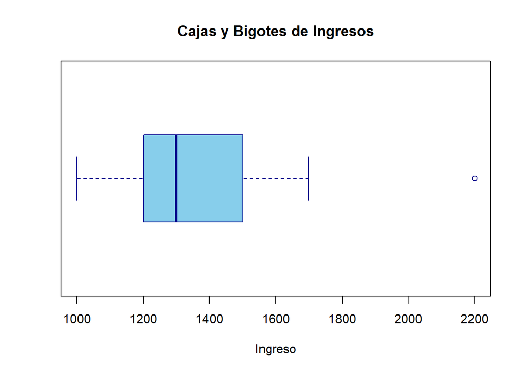

```r
boxplot(
  data_sin_errores$Ingreso,
  horizontal = TRUE,
  col = "skyblue",
  border = "darkblue",
  main = "Cajas y Bigotes de Ingresos",
  xlab = "Ingreso")
```

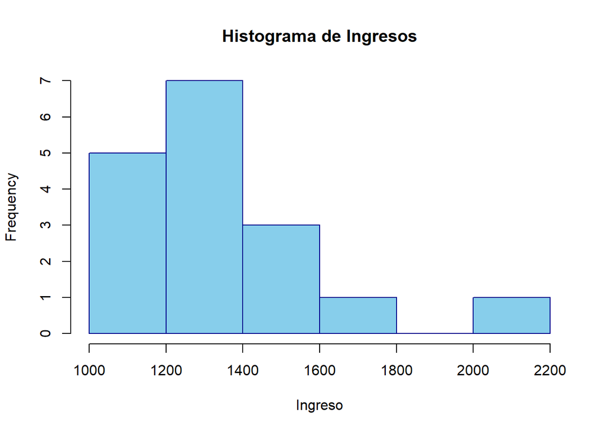

```r
hist(
  data_sin_errores$Ingreso,
  horizontal = TRUE,
  col = "skyblue",
  border = "darkblue",
  main = "Histograma de Ingresos",
  xlab = "Ingreso")
```

## ESTANDARIZACIÓN DE VARIABLES

```r
data_sin_errores$Ingreso_est <- scale(data_sin_errores$Ingreso)
```

```r
summary(data_sin_errores$Ingreso_est)
```

```
##        V1
##  Min.   :-1.3546
##  1st Qu.:-0.6405
##  Median :-0.2835
##  Mean   : 0.0000
##  3rd Qu.: 0.4305
##  Max.   : 2.9296
```

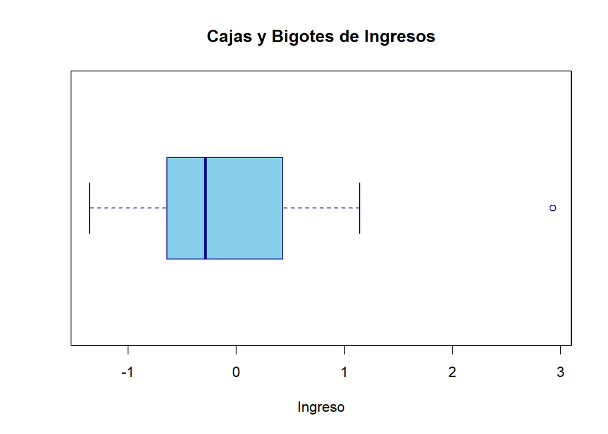

```r
boxplot(
  data_sin_errores$Ingreso_est,
  horizontal = TRUE,
  col = "skyblue",
  border = "darkblue",
  main = "Cajas y Bigotes de Ingresos",
  xlab = "Ingreso")
```

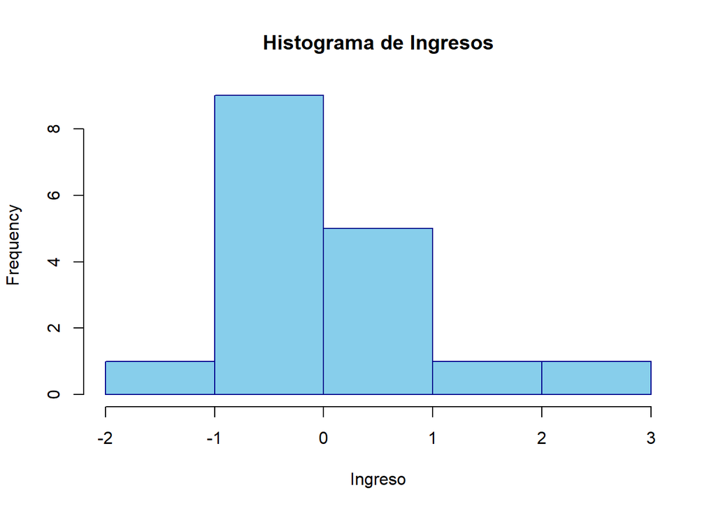

```r
hist(
  data_sin_errores$Ingreso_est,
  horizontal = TRUE,
  col = "skyblue",
  border = "darkblue",
  main = "Histograma de Ingresos",
  xlab = "Ingreso")
```

La normalización Min-Max y la transformación de variables son técnicas complementarias de preprocesamiento utilizadas para adecuar la escala y la forma de los datos antes del modelado estadístico. Por un lado, la normalización Min-Max aplica un reescalamiento lineal que comprime los valores originales dentro de un intervalo fijo —habitualmente $[0, 1]$— mediante la ecuación $x'_i = \frac{x_i - \min(x)}{\max(x) - \min(x)}$, lo que garantiza que todas las variables contribuyan equitativamente en algoritmos sensibles a la magnitud, sin alterar la estructura de la distribución. Por otro lado, la transformación de datos (como la logarítmica $y_i = \ln(x_i)$, raíz cuadrada $y_i = \sqrt{x_i}$ o Box-Cox) modifica de manera no lineal la forma misma de la variable para corregir sesgos pronunciados, estabilizar la varianza (homocedasticidad) y acercar los datos a una distribución normal. En el flujo de trabajo de un análisis reproducible en R Markdown, ambas estrategias suelen aplicarse de forma secuencial cuando los datos presentan tanto asimetría como escalas dispares. Primero se ejecuta la transformación no lineal (por ejemplo, log1p(x) en R para evitar errores con valores cero) con el fin de mitigar el impacto de colas largas y valores extremos; posteriormente, sobre la variable ya simetrizada, se aplica el escalamiento Min-Max. Este orden evita que los valores atípicos originales distorsionen los límites $\min(x)$ y $\max(x)$, asegurando que los datos transformados queden acotados de manera uniforme y listos para alimentar modelos predictivos de forma estable.